**2023年度 東京成徳大学 特別講座 資料**  
**東京工科大学コンピュータサイエンス学部**  
**福西広晃**

Pythonの基礎

# 制御構文

- プログラムに高度な機能（電卓以上）を持たせるためには制御構文が必要
- 制御構文とは、プログラムの実行順序を制御するためにもの
- プログラムは、`順次`，`選択（分岐）`，`反復（繰り返し、ループ)`の3つ制御構文の組み合わせである
- この3つによって、あらゆる実行順序が記述できる

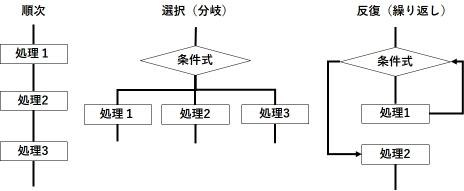

# 反復（繰り返し、ループ）

- 反復（繰り返し、ループ）には`for文`や`while文`を用いる
- `for文`は、指定した回数を繰り返す（繰り返し範囲を指定するためには、リストやrangeをin演算子とともに用いる）
- `while文`は、ある条件を満たすまで繰り返す
- 繰り返しの途中で処理を中断したい場合には、`break文`を使う
- 繰り返しの途中で特定の処理だスキップしたい場合には、`continue文`を使う

**今回は、特に重要なfor文を扱います。**

# 順次で記述した場合（for文を使わない）

同じ処理を何度も記述する必要があり、プログラミング効率が悪い

**0から9までの整数をカンマ区切りで表示する例**

```python
print(0, end=',') # 末尾は改行ではなくコンマに指定
print(1, end=',')
print(2, end=',')
print(3, end=',')
print(4, end=',')
print(5, end=',')
print(6, end=',')
print(7, end=',')
print(8, end=',')
print(9, end=',')
```

```
0,1,2,3,4,5,6,7,8,9,
```

## 練習

「programming language」をカンマ区切りで5回繋げて１行で表示してみよう。

解答例

```python
print("programming language", end=',') # 末尾は改行ではなくコンマに指定
print("programming language", end=',')
print("programming language", end=',')
print("programming language", end=',')
print("programming language", end=',')
```

```
programming language,programming language,programming language,programming language,programming language,
```

# for文を用いた反復（繰り返し、ループ）

繰り返し範囲を指定するためには、`range関数`や`リスト`のオブジェクト（データの集合）をin演算子とともに用いる。  
データを1個ずつ変数に代入して反復処理を行う

```
for 変数 in オブジェクト:
    実行する処理
```

**[注意事項]**

- for文の処理を記述する際は`空白（半角スペース）を入れて字下げ`しなければならない（「`インデントを揃える`」という）。通常、半角スペース4つ
- 毎回半角スペースのキーを4回打つのは面倒なので、`Tab`キーを押せば自動的に調整してくれる
- **リストについては、次回の学習予定のためrange関数のみを扱う**

## `range関数`の使い方

```
range(n)
```

- **`0`から`n-1`までの`n個`の整数を順番に並べたデータ集合を生成**
- 例えば、range(3)の場合、{0,1,2}のデータの集合が生成される
- for文では0,1,2を順番に変数に代入して処理を繰り返す(つまり、3回処理を反復)

```
range(開始番号, 終了番号)
```

- 開始番号から開始して、 `終了番号-1`までの整数を順番に並べたデータ集合を生成

```
range(開始番号, 終了番号, ステップ数)
```

- 開始番号から開始して、 `終了番号-1`まで、ステップ数の間隔で整数を順番に並べたデータ集合を生成

## range関数によりN回繰り返す

**0から9までの整数をカンマ区切りで表示するプログラム**

```python
for i in range(10):
    print(i, end=',')
```

```
0,1,2,3,4,5,6,7,8,9,
```

**「programming languate」をカンマ区切りで10回表示するプログラム**

```python
for i in range(10):
    print("programming language", end=',')
```

```
programming language,programming language,programming language,programming language,programming language,programming language,programming language,programming language,programming language,programming language,
```

## range関数により特定の範囲で繰り返す

**5から9までの整数をカンマ区切りで表示するプログラム**

```python
for i in range(5, 10):  # 終了番号は1加える
    print(i, end=',')
```

```
5,6,7,8,9,
```

## range関数により特定の間隔で繰り返す

**0から9までの偶数をカンマ区切りで表示するプログラム**

```python
for i in range(0, 10, 2):  # 終了番号は1加える
    print(i, end=',')
```

```
0,2,4,6,8,
```

### 練習

(1) for文を使って0から199までの整数を空白区切りで表示してみよう

(2) for文を使って9999の整数を15回空白区切りで表示してみよう

(3) for文を使って342から365までの整数を空白区切りで表示してみよう

(4) for文を使って3から30までの3の倍数を空白区切りで表示してみよう

解答例

```python
#(1)
for i in range(200):
    print(i, end=' ')
```

[output not shown]

```python
#(2)
for i in range(15):
    print(9999, end=' ')
```

```
9999 9999 9999 9999 9999 9999 9999 9999 9999 9999 9999 9999 9999 9999 9999
```

```python
#(3)
for i in range(342, 366): # 終了番号は1加える
    print(i, end=' ')
```

```
342 343 344 345 346 347 348 349 350 351 352 353 354 355 356 357 358 359 360 361 362 363 364 365
```

```python
#(4)
for i in range(3, 31, 3):  # 終了番号は1加える
    print(i, end=' ')
```

```
3 6 9 12 15 18 21 24 27 30
```

# for文を使った演算

## 整数の合計値を計算

**1から100までの整数を合計するプログラム**

```python
total = 0                 # 合計を保持する変数で、初期値を0としておく

for i in range(1, 101):  # 終了番号は1加える
    total = total + i    # totalにiを加算

print("合計: ", total)    # 合計出力
```

```
合計:  5050
```

**1から100までの偶数を合計するプログラム**

```python
total = 0                   # 合計を保持する変数で、初期値を0としておく

for i in range(2, 101, 2): # 開始番号は2, 終了番号は1加える
    total = total + i      # totalにiを加算

print("合計: ", total)     # 合計出力
```

```
合計:  2550
```

## 練習

(1) 1から10000までの奇数の合計を計算してみよう。合計を表す変数は`total`とする。最後に合計を出力してみよう。

(2) 初期投資が1000円で、毎日の利率が0.1%で運用した場合、365日後にはいくらになるかを計算してみよう（365回の繰り返し）。初期投資額を表す変数は`initial`、合計を表す変数は`total`とする。最後に初期投資からの利益を出力してみよう。

解答例

```python
# (1)
total = 0                      # 合計を保存する変数で、初期値を0としておく
for i in range(1, 10001, 2):  # 終了番号は1加える
    total = total + i         # totalにiを加算

print("合計: ", total)          # 合計出力
```

```
合計:  25000000
```

```python
# (2)
initial = 1000               # 初期投資額
total   = initial            # 初期の合計金額
for i in range(365):        # 繰り返し回数
    total = total*1.001     # totalに1.001を掛ける

print("利益: ", total-initial, "円") # 利益出力
```

```
利益:  440.2513134295191 円
```

# for文とif文の組み合わせ

**1から1000までの整数の中で、7の倍数以外の合計を計算するプログラム**

```python
total = 0                      # 合計を保存する変数で、初期値を0としておく
for i in range(1, 1001):      # 終了番号は1加える
    amari = i%7               # あまり計算
    if amari != 0:           # 条件
        total = total + i     # totalにiを加算

print("合計: ", total)        # 合計出力
```

```
合計:  429429
```

**8月に31日間アルバイトをしたとする。1日目から15日目までは日給は3000円、16日目から31日目までは3500円であった場合、8月の合計収入を計算してみよう。for文でカレンダー上の1日から31日まで反復とする。**

```python
total = 0                      # 合計を保存する変数で、初期値を0としておく

for i in range(1, 32):         # カレンダーの1日から31日まで繰り返し(終了番号に1加える)
    if i <= 15:
        total = total + 3000   # 3000を加算
    else:
        total = total + 3500   # 3500を加算

print("合計: ", total, "円")   # 合計出力
```

```
合計:  101000 円
```

## 練習

(1) 1から500までの整数の中で、5の倍数以外の合計を計算してみよう。合計を表す変数は`total`とする。最後に合計を出力してみよう。

(2) 8月に31日間アルバイトをしたとする。偶数の日の日給は4100円、奇数の日の日給は3800円であった場合、8月の合計収入を計算してみよう。for文でカレンダー上の1日から31日まで反復とする。偶数と奇数の判定は、2で割った余りが0か0以外かで判定できる。合計を表す変数は`total`とする。最後に合計を出力してみよう。

解答例

```python
#(1)
total = 0                      # 合計を保存する変数で、初期値を0としておく
for i in range(1, 501):       # 終了番号は1加える
    amari = i%5               # あまり計算
    if amari != 0:            # 条件
        total = total + i     # totalにiを加算

print("合計: ", total)        # 合計出力
```

```
合計:  100000
```

```python
# (2)
total = 0                       # 合計を保存する変数で、初期値を0としておく
for i in range(1, 32):         # カレンダーの1日から31日まで繰り返し(終了番号に1加える)
    if i % 2 == 0:            # 偶数の日の判定
        total = total + 4100   # 4100加算
    else:                      # 奇数の日
        total = total + 3800   # 3800加算

print("合計収入:", total,"円") # 合計出力
```

```
合計収入: 122300 円
```